```python
from IPython.display import HTML
HTML('''<script>
code_show=true;
function code_toggle() {
 if (code_show){
 $('div.input').hide();
 } else {
 $('div.input').show();
 }
 code_show = !code_show
}
$( document ).ready(code_toggle);
</script>
The raw code for this IPython notebook is by default hidden for easier reading.
To toggle on/off the raw code, click <a href="javascript:code_toggle()">here</a>.''')
```

The raw code for this IPython notebook is by default hidden for easier reading. To toggle on/off the raw code, click here.

# Topic Modelling

Topic Modelling is a process to automatically identify topics present in a text object and to derive hidden patterns exhibited by a text corpus. Thus, assisting better decision making. Topic Modelling is different from rule-based text mining approaches that use regular expressions or dictionary based keyword searching techniques. It is an unsupervised approach used for finding and observing the bunch of words (called “topics”) in large clusters of texts. Topic Models are very useful for the purpose for document clustering, organizing large blocks of textual data, information retrieval from unstructured text and feature selection.

```python
import pandas as pd
import numpy as np
import nltk
import re
from pprint import pprint

import gensim
import gensim.corpora as corpora
from gensim.utils import simple_preprocess
from gensim.models import CoherenceModel


import spacy  ## spacy is their for lemmatization

# Plotting tools
import pyLDAvis
import pyLDAvis.gensim
import matplotlib.pyplot as plt
%matplotlib inline



# Enable logging for gensim - optional
import logging
logging.basicConfig(format='%(asctime)s : %(levelname)s : %(message)s', level=logging.ERROR)

import warnings
warnings.filterwarnings("ignore",category=DeprecationWarning)
```

```python
import warnings
warnings.filterwarnings("ignore")
```

# Topic modelling for promoter

```python
import sys
# !{sys.executable} -m spacy download en
import re, numpy as np, pandas as pd
from pprint import pprint

# Gensim
import gensim, spacy, logging, warnings
import gensim.corpora as corpora
from gensim.utils import lemmatize, simple_preprocess
from gensim.models import CoherenceModel
import matplotlib.pyplot as plt

# NLTK Stop words
from nltk.corpus import stopwords
stop_words = stopwords.words('english')
stop_words.extend(['from', 'subject', 're', 'edu', 'use', 'not', 'would', 'say', 'could', '_', 'be', 'know', 'good', 'go', 'get', 'do', 'done', 'try', 'many', 'some', 'nice', 'thank', 'think', 'see', 'rather', 'easy', 'easily', 'lot', 'lack', 'make', 'want', 'seem', 'run', 'need', 'even', 'right', 'line', 'even', 'also', 'may', 'take'])

%matplotlib inline
warnings.filterwarnings("ignore",category=DeprecationWarning)
logging.basicConfig(format='%(asctime)s : %(levelname)s : %(message)s', level=logging.ERROR)
```

```python
df=pd.read_excel("C:/Users/91903/Desktop/BETSOL/text report/medallia(213_226).xlsx",skiprows=2)
#df.shape
```

```python
data=df[['Phone tNPS','Phone Reason for Score']]
data['Customer Type'] = data['Phone tNPS'].apply(lambda x: "Detractor" if x>=0 and x<=6 else ("Passive" if x>=7 and x<=8 else "Promoter"))


dataPromoter=data[data['Customer Type']=='Promoter']
commentsPromoter=dataPromoter['Phone Reason for Score']
x_promoter=commentsPromoter.dropna()


dataDetractor=data[data['Customer Type']=='Detractor']
commentsDetractor=dataDetractor['Phone Reason for Score']
x_detractor=commentsDetractor.dropna()
```

```python
def sent_to_words(sentences):
    for sent in sentences:
        sent = re.sub('\S*@\S*\s?', '', sent)  # remove emails
        sent = re.sub('\s+', ' ', sent)  # remove newline chars
        sent = re.sub("\'", "", sent)  # remove single quotes
        sent = gensim.utils.simple_preprocess(str(sent), deacc=True)
        yield(sent)

# Convert to list
data = x_promoter.tolist()
data_words = list(sent_to_words(data))
#print(data_words[:1])
```

```python
# Building the bigram and trigram models
bigram = gensim.models.Phrases(data_words, min_count=1, threshold=300) # higher threshold fewer phrases.
trigram = gensim.models.Phrases(bigram[data_words], threshold=100)
bigram_mod = gensim.models.phrases.Phraser(bigram)
trigram_mod = gensim.models.phrases.Phraser(trigram)

# !python3 -m spacy download en  # run in terminal once
def process_words(texts, stop_words=stop_words, allowed_postags=['NOUN', 'ADJ', 'VERB', 'ADV']):
    """Remove Stopwords, Form Bigrams, Trigrams and Lemmatization"""
    texts = [[word for word in simple_preprocess(str(doc)) if word not in stop_words] for doc in texts]
    texts = [bigram_mod[doc] for doc in texts]
    texts = [trigram_mod[bigram_mod[doc]] for doc in texts]
    texts_out = []
    nlp = spacy.load('en', disable=['parser', 'ner'])
    for sent in texts:
        doc = nlp(" ".join(sent))
        texts_out.append([token.lemma_ for token in doc if token.pos_ in allowed_postags])
    # remove stopwords once more after lemmatization
    texts_out = [[word for word in simple_preprocess(str(doc)) if word not in stop_words] for doc in texts_out]
    return texts_out

data_ready = process_words(data_words)
```

```python
# Create Dictionary
id2word = corpora.Dictionary(data_ready)

# Create Corpus: Term Document Frequency
corpus = [id2word.doc2bow(text) for text in data_ready]

# Build LDA model
lda_model = gensim.models.ldamodel.LdaModel(corpus=corpus,
                                           id2word=id2word,
                                           num_topics=4,
                                           random_state=100,
                                           update_every=1,
                                           chunksize=10,
                                           passes=10,
                                           alpha='symmetric',
                                           iterations=100,
                                           per_word_topics=True)

pprint(lda_model.print_topics())
```

```
[(0,
  '0.129*"service" + 0.083*"helpful" + 0.076*"comcast" + 0.059*"person" + '
  '0.058*"customer" + 0.030*"really" + 0.029*"people" + 0.026*"patient" + '
  '0.026*"knowledgeable" + 0.024*"extremely"'),
 (1,
  '0.062*"give" + 0.055*"representative" + 0.045*"work" + 0.044*"polite" + '
  '0.033*"today" + 0.028*"understand" + 0.026*"kind" + 0.021*"wonderful" + '
  '0.019*"quickly" + 0.017*"issue"'),
 (2,
  '0.097*"help" + 0.068*"call" + 0.063*"always" + 0.054*"talk" + 0.051*"speak" '
  '+ 0.039*"question" + 0.039*"answer" + 0.034*"agent" + 0.027*"great" + '
  '0.025*"appreciate"'),
 (3,
  '0.130*"problem" + 0.052*"time" + 0.033*"phone" + 0.031*"fix" + '
  '0.030*"solve" + 0.029*"recommend" + 0.025*"come" + 0.024*"last" + '
  '0.023*"courteous" + 0.022*"first"')]
```

```python
# Visualize the topics
pyLDAvis.enable_notebook()
vis = pyLDAvis.gensim.prepare(lda_model, corpus, id2word)
vis
```

[interactive chart not shown]

A good topic model will have fairly big, non-overlapping bubbles scattered throughout the chart instead of being clustered in one quadrant .

### Insight -

Topic 1- Service Related -- Good Service ( Knowledge, Helpful )

Topic 2- Resolution Related -- (Timely ,Problem Fixed, Recommendation)

Topic 3- Behaviour -- (Agent Performance)

Topic 4- Comcast Representative -- (Field Service Agent)

# Wordcount for topic

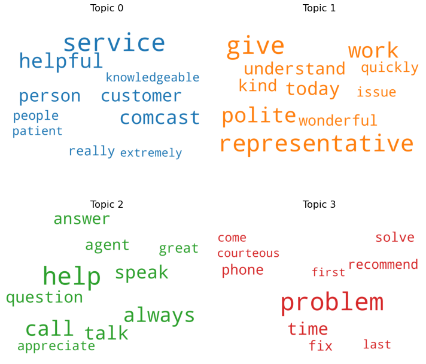

```python
# 1. Wordcloud of Top N words in each topic
from matplotlib import pyplot as plt
from wordcloud import WordCloud, STOPWORDS
import matplotlib.colors as mcolors

cols = [color for name, color in mcolors.TABLEAU_COLORS.items()]  # more colors: 'mcolors.XKCD_COLORS'

cloud = WordCloud(stopwords=stop_words,
                  background_color='white',
                  width=2500,
                  height=1800,
                  max_words=10,
                  colormap='tab10',
                  color_func=lambda *args, **kwargs: cols[i],
                  prefer_horizontal=1.0)

topics = lda_model.show_topics(formatted=False)

fig, axes = plt.subplots(2, 2, figsize=(10,10),sharex=True, sharey=True)

for i, ax in enumerate(axes.flatten()):
    fig.add_subplot(ax)
    topic_words = dict(topics[i][1])
    cloud.generate_from_frequencies(topic_words, max_font_size=300)
    plt.gca().imshow(cloud)
    plt.gca().set_title('Topic ' + str(i), fontdict=dict(size=16))
    plt.gca().axis('off')


plt.subplots_adjust(wspace=0, hspace=0)
plt.axis('off')
plt.margins(x=0, y=0)
plt.tight_layout()
plt.show()
```

## Topic's for Detractor

```python
def sent_to_words(sentences):
    for sent in sentences:
        sent = re.sub('\S*@\S*\s?', '', sent)  # remove emails
        sent = re.sub('\s+', ' ', sent)  # remove newline chars
        sent = re.sub("\'", "", sent)  # remove single quotes
        sent = gensim.utils.simple_preprocess(str(sent), deacc=True)
        yield(sent)

# Convert to list
data = x_detractor.tolist()
data_words = list(sent_to_words(data))
#print(data_words[:2])
```

```python
# Build the bigram and trigram models
bigram = gensim.models.Phrases(data_words, min_count=1, threshold=300) # higher threshold fewer phrases.
trigram = gensim.models.Phrases(bigram[data_words], threshold=200)
bigram_mod = gensim.models.phrases.Phraser(bigram)
trigram_mod = gensim.models.phrases.Phraser(trigram)

# !python3 -m spacy download en  # run in terminal once
def process_words(texts, stop_words=stop_words, allowed_postags=['NOUN', 'ADJ', 'VERB', 'ADV']):
    """Remove Stopwords, Form Bigrams, Trigrams and Lemmatization"""
    texts = [[word for word in simple_preprocess(str(doc)) if word not in stop_words] for doc in texts]
    texts = [bigram_mod[doc] for doc in texts]
    texts = [trigram_mod[bigram_mod[doc]] for doc in texts]
    texts_out = []
    nlp = spacy.load('en', disable=['parser', 'ner'])
    for sent in texts:
        doc = nlp(" ".join(sent))
        texts_out.append([token.lemma_ for token in doc if token.pos_ in allowed_postags])
    # remove stopwords once more after lemmatization
    texts_out = [[word for word in simple_preprocess(str(doc)) if word not in stop_words] for doc in texts_out]
    return texts_out

data_ready = process_words(data_words)
```

```python
# Create Dictionary
id2word = corpora.Dictionary(data_ready)

# Create Corpus: Term Document Frequency
corpus = [id2word.doc2bow(text) for text in data_ready]

# Build LDA model
lda_model = gensim.models.ldamodel.LdaModel(corpus=corpus,
                                           id2word=id2word,
                                           num_topics=4,
                                           random_state=100,
                                           update_every=1,
                                           chunksize=10,
                                           passes=10,
                                           alpha='symmetric',
                                           iterations=100,
                                           per_word_topics=True)

pprint(lda_model.print_topics())
```

```
[(0,
  '0.048*"fix" + 0.041*"time" + 0.034*"guy" + 0.030*"expensive" + '
  '0.028*"system" + 0.027*"issue" + 0.025*"cable" + 0.024*"turn" + '
  '0.023*"message" + 0.023*"automate"'),
 (1,
  '0.103*"service" + 0.050*"problem" + 0.041*"phone" + 0.032*"customer" + '
  '0.032*"person" + 0.030*"speak" + 0.028*"pay" + 0.027*"work" + 0.027*"talk" '
  '+ 0.023*"give"'),
 (2,
  '0.101*"call" + 0.035*"tv" + 0.030*"come" + 0.029*"today" + 0.029*"time" + '
  '0.028*"back" + 0.027*"wait" + 0.023*"day" + 0.023*"hour" + 0.021*"week"'),
 (3,
  '0.056*"comcast" + 0.031*"people" + 0.030*"bill" + 0.027*"high" + '
  '0.027*"price" + 0.024*"month" + 0.021*"give" + 0.021*"year" + '
  '0.016*"recommend" + 0.016*"way"')]
```

```python
# Visualize the topics
pyLDAvis.enable_notebook()
vis = pyLDAvis.gensim.prepare(lda_model, corpus, id2word)
vis
```

[interactive chart not shown]

A good topic model will have fairly big, non-overlapping bubbles scattered throughout the chart instead of being clustered in one quadrant .

### Insight -

Topic 1- Wait Time - Delay in Resolution

Topic 2- Service related issues -- (Bill,Payments,Issues Not resolved).

Topic 3- High Billing By Comcast.

Topic 4- Costly Resolution.(Cost , Time)

# Wordcount for topics

[figure not shown]

```python
# 1. Wordcloud of Top N words in each topic
from matplotlib import pyplot as plt
from wordcloud import WordCloud, STOPWORDS
import matplotlib.colors as mcolors

cols = [color for name, color in mcolors.TABLEAU_COLORS.items()]  # more colors: 'mcolors.XKCD_COLORS'

cloud = WordCloud(stopwords=stop_words,
                  background_color='white',
                  width=2500,
                  height=1800,
                  max_words=10,
                  colormap='tab10',
                  color_func=lambda *args, **kwargs: cols[i],
                  prefer_horizontal=1.0)

topics = lda_model.show_topics(formatted=False)

fig, axes = plt.subplots(2, 2, figsize=(10,10), sharex=True, sharey=True)

for i, ax in enumerate(axes.flatten()):
    fig.add_subplot(ax)
    topic_words = dict(topics[i][1])
    cloud.generate_from_frequencies(topic_words, max_font_size=300)
    plt.gca().imshow(cloud)
    plt.gca().set_title('Topic ' + str(i), fontdict=dict(size=16))
    plt.gca().axis('off')


plt.subplots_adjust(wspace=0, hspace=0)
plt.axis('off')
plt.margins(x=0, y=0)
plt.tight_layout()
plt.show()
```